# Second R Practical: Data Frames & Factors

# Cleaning up data

We’ve discussed how data ought to be tidily organized, and we’ve now gone over how to load data, and minimally explore dataframes in R. Let’s quickly go over how to tidy up messy data a little.

First, let’s look at the wide `iy_ah_wide` dataframe, which is part of the `lsa2017` package.

```r
iy_ah_wide
```

|  | idstring | age | sex | year | ah_F1 | ah_F2 | iy_F1 | iy_F2 |
| --- | --- | --- | --- | --- | --- | --- | --- | --- |
| 1 | PH00-1-1- | 21 | m | 2000 | 661.3866 | 1278.020 | 441.0271 | 2034.065 |
| 2 | PH00-1-2- | 52 | f | 2000 | 831.4035 | 1391.976 | 406.0202 | 2450.472 |
| 3 | PH00-1-3- | 18 | m | 2000 | 631.2241 | 1267.028 | 371.8246 | 1915.340 |
| 4 | PH00-1-4- | 18 | m | 2000 | 664.1353 | 1262.315 | 400.6728 | 2025.175 |
| 5 | PH00-1-5- | 70 | m | 2000 | 715.8319 | 1253.072 | 381.0250 | 2089.078 |
| 6 | PH00-2-1- | 65 | f | 2000 | 753.2472 | 1387.222 | 414.3717 | 2305.639 |
| 7 | PH02-1-1- | 93 | f | 2002 | 762.6000 | 1517.871 | 447.8636 | 2325.591 |
| 8 | PH02-2-12- | 19 | f | 2002 | 1025.6174 | 1720.891 | 494.7294 | 2728.676 |
| 9 | PH02-2-4- | 63 | f | 2002 | 828.9702 | 1485.866 | 421.5275 | 2572.296 |
| 10 | PH02-2-5- | 59 | f | 2002 | 798.3188 | 1322.367 | 406.6214 | 2488.733 |

[output cut: 282 more lines]

The problem with this data is

- There are *values* spread across the columns.
- Individual column names have combined these *values* with some *variables*.

Getting to a tidier format of the data will involve a three step process:

1. Converting this wide data format to a long data format.
2. Separating the vowel class values from the formant variable.
3. Spreading the formant variables back out along the column space.’

We can do this easily with the functions `gather()`, `separate()` and `spread()` from the `tidyr` package.

For a smaller illustrative purpose for people who may feel uneasy about vowels and formants, I’ll be illustrating each of these steps with a simpler data set about how many apples and oranges two people bought, and how many they ate.

```r
fruit <- data.frame(person = c("Oakley", "Charlie"),
                 apples_bought = c(5, 3),
                 apples_ate = c(1, 2),
                 oranges_bought = c(5, 4),
                 oranges_ate = c(3, 3))
```

| person | apples_bought | apples_ate | oranges_bought | oranges_ate |
| --- | --- | --- | --- | --- |
| Oakley | 5 | 1 | 5 | 3 |
| Charlie | 3 | 2 | 4 | 3 |

Note, even though the column labels look different, this is is an equivalent table to formatting involving merged column label cells.

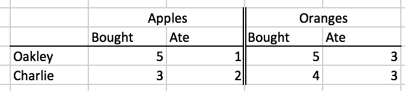

## Gathering Columns

The `gather()` function makes *wide* data *long.* It takes the following arguments:

gather(data, key, value, cols)

- `data`
  - Obviously, the data you want to reshape. must be a data frame.
- `key` and `value`
  - These are new column names that you want to create. `gather()` is going to take the column names and put them in the column you give to `key`, and the values from all the cells and put them in the column you call `value`.
- `cols`
  - An indication of which columns you want to gather, either a vector of column names, a vector of column numbers, or some specialized methods for `gather()` that we’ll discuss.

Here’s how that’ll work for the fruit data. We’ll tell `gather()` to gather columns 2 through 5.

```r
fruit_long <- gather(data = fruit,
                     key = fruit_behavior,
                     value = number,
                     2:5)
```

| person | fruit_behavior | number |
| --- | --- | --- |
| Oakley | apples_bought | 5 |
| Charlie | apples_bought | 3 |
| Oakley | apples_ate | 1 |
| Charlie | apples_ate | 2 |
| Oakley | oranges_bought | 5 |
| Charlie | oranges_bought | 4 |
| Oakley | oranges_ate | 3 |
| Charlie | oranges_ate | 3 |

`gather()` has returned a new data frame. It has created a new column called `fruit_behavior`, because we told it to with the `key` argument, and it has created a new column called `number`, because we told it to with the `value` function. It has taken all of the column names of the columns we told it to gather, and put them into the `fruit_behavior` column, and the numeric values from the columns we told it to gather, and put them into the `number` column. It has also repeated the rows of the other columns (`person`) as logically necessary.

Now, we told it to gather column numbers 2 through 5, but this would have also worked:

```r
gather(data = fruit,
       key = fruit_behavior,
       value = number,
       c("apples_bought","apples_ate", "oranges_bought", "oranges_ate"))
```

| person | fruit_behavior | number |
| --- | --- | --- |
| Oakley | apples_bought | 5 |
| Charlie | apples_bought | 3 |
| Oakley | apples_ate | 1 |
| Charlie | apples_ate | 2 |
| Oakley | oranges_bought | 5 |
| Charlie | oranges_bought | 4 |
| Oakley | oranges_ate | 3 |
| Charlie | oranges_ate | 3 |

`gather()` also has a more convenient method of specifying the columns you want to gather by passing it a named range of columns. We want to gather all columns from `apples_bought` to `oranges_ate`, so we can tell it to do so with `apples_bought:oranges_ate`.

```r
gather(data = fruit,
       key = fruit_behavior,
       value = number,
       apples_bought:oranges_ate)
```

| person | fruit_behavior | number |
| --- | --- | --- |
| Oakley | apples_bought | 5 |
| Charlie | apples_bought | 3 |
| Oakley | apples_ate | 1 |
| Charlie | apples_ate | 2 |
| Oakley | oranges_bought | 5 |
| Charlie | oranges_bought | 4 |
| Oakley | oranges_ate | 3 |
| Charlie | oranges_ate | 3 |

Ok, let’s do this now to the `iy_ah_wide` data, gathering all of the columns from `ah_F1` to `iy_F2`.

```r
iy_ah_step1 <- gather(data = iy_ah_wide,
                      key = vowel_formant,
                      value = hz,
                      ah_F1:iy_F2)
iy_ah_step1
```

| idstring | age | sex | year | vowel_formant | hz |
| --- | --- | --- | --- | --- | --- |
| PH00-1-1- | 21 | m | 2000 | ah_F1 | 661.3866 |
| PH00-1-2- | 52 | f | 2000 | ah_F1 | 831.4035 |
| PH00-1-3- | 18 | m | 2000 | ah_F1 | 631.2241 |
| PH00-1-4- | 18 | m | 2000 | ah_F1 | 664.1353 |
| PH00-1-5- | 70 | m | 2000 | ah_F1 | 715.8319 |
| PH00-2-1- | 65 | f | 2000 | ah_F1 | 753.2472 |
| PH02-1-1- | 93 | f | 2002 | ah_F1 | 762.6000 |
| PH02-2-12- | 19 | f | 2002 | ah_F1 | 1025.6174 |
| PH02-2-4- | 63 | f | 2002 | ah_F1 | 828.9702 |
| PH02-2-5- | 59 | f | 2002 | ah_F1 | 798.3188 |

[output cut: 990 more lines]

For the fruit data, the only un-gathered column was `person`, but for `iy_ah_wide`, `idstring`, `age`, `sex`, and `year`, were all ungathered. Here you can see how all rows of ungathered columns are repeated as logically necessary.

## Separating Columns

There is still a problem with both the `fruit_long` and the `iy_ah_step1` data frames, which is that two different kinds of data are merged within one column. For `iy_ah_step1`, the vowel class and formant variable are merged together (e.g. `ah_F1`) and for `fruit_long`, the fruit and behavior are merged together (e.g. `apple_bought`). We need to separate these, with a very aptly named function called `separate()`

separate(data, col, into, sep)

- `data`
  - Again,the data frame you want to do this separation to.
- `col`
  - The name of the column you want to separate.
- `into`
  - A character vector of the new column names you want to create.
- `sep`
  - The character or regex pattern you want to use to split up the values in `col`.

Here’s how it works for `fruit_long`.

```r
fruit_separate <- separate(data = fruit_long,
                           col = fruit_behavior,
                           into = c("fruit", "behavior"),
                           sep = "_")
```

| person | fruit | behavior | number |
| --- | --- | --- | --- |
| Oakley | apples | bought | 5 |
| Charlie | apples | bought | 3 |
| Oakley | apples | ate | 1 |
| Charlie | apples | ate | 2 |
| Oakley | oranges | bought | 5 |
| Charlie | oranges | bought | 4 |
| Oakley | oranges | ate | 3 |
| Charlie | oranges | ate | 3 |

It has returned a new data frame with the `fruit_behavior` column split into two new columns, named after what I passed to the `into` argument. It split up `fruit_behavior` based on what I passed to `sep`, which was the underscore character.

Let’s do this for `iy_ah_step1` now.

```r
iy_ah_step2 <- separate(iy_ah_step1,
                        vowel_formant,
                        into = c("vowel", "formant"),
                        sep = "_")
iy_ah_step2
```

|  | idstring | age | sex | year | vowel | formant | hz |
| --- | --- | --- | --- | --- | --- | --- | --- |
| 1 | PH00-1-1- | 21 | m | 2000 | ah | F1 | 661.3866 |
| 2 | PH00-1-2- | 52 | f | 2000 | ah | F1 | 831.4035 |
| 3 | PH00-1-3- | 18 | m | 2000 | ah | F1 | 631.2241 |
| 4 | PH00-1-4- | 18 | m | 2000 | ah | F1 | 664.1353 |
| 5 | PH00-1-5- | 70 | m | 2000 | ah | F1 | 715.8319 |
| 6 | PH00-2-1- | 65 | f | 2000 | ah | F1 | 753.2472 |
| 7 | PH02-1-1- | 93 | f | 2002 | ah | F1 | 762.6000 |
| 8 | PH02-2-12- | 19 | f | 2002 | ah | F1 | 1025.6174 |
| 9 | PH02-2-4- | 63 | f | 2002 | ah | F1 | 828.9702 |
| 10 | PH02-2-5- | 59 | f | 2002 | ah | F1 | 798.3188 |

[output cut: 990 more lines]

We now have two separate columns for `vowel` and `formant`.

Hygiene

I have been very helpful and used underscores to merge together the values we want to separate. Be helpful to yourself, and be consistent in the semantics of how you used potential delimiters like `-` and `_`. Here’s an example of being helpful to yourself:

```
project_subject_firstname-lastname

EDI_1_Stuart-Duddingston
EDI_2_Connor-Black-Macdowall
EDI_3_Mhairi
```

This is helpful, because when you separate by underscore, you’ll have something tidy

```
EDI    1    Stuart-Duddingston
EDI    2    Connor-Black-Macdowall
EDI    3    Mhairi
```

If you used `-` for everything, you’ll have chaos when you try to separate them because some speakers have “double barreled” names, and some speakers have only first names:

```
# Input:
EDI-1-Stuart-Duddingston
EDI-2-Connor-Black-Macdowall
EDI-3-Mhairi

# Becomes

EDI    1    Stuart    Duddingston
EDI    2    Connor    Black        Macdowall
EDI    3    Mhairi
```

This goes beyond R programming. You should make some decisions and stick with them for all of your data analysis, including file naming, Praat tier naming, etc.

## Spreading columns

We’ve got one last step, which is spreading the values in some rows across the column space. With the `fruit` data, we might not want a column called `behavior`, but actually have two columns called `bought` and `ate`. For the vowel data, we definitely don’t want one column called `formant`. We want one called `F1` and one called `F2`. We can do this with the `spread()` function.

spread(data, key, value)

- `data`
  - Again, the data we want to work with.
- `key`
  - The column whose values you want to spread across the column space.
- `value`
  - The column with values that you want to fill in the cells.

Here’s how that looks with the `fruit_separate` data.

```r
fruit_spread <- spread(data = fruit_separate,
                       key = behavior,
                       value = number)
```

| person | fruit | ate | bought |
| --- | --- | --- | --- |
| Charlie | apples | 2 | 3 |
| Charlie | oranges | 3 | 4 |
| Oakley | apples | 1 | 5 |
| Oakley | oranges | 3 | 5 |

This has created a new data frame. I told `spread()` to spread the values in `behavior` across the column space. Because it had only two unique values in it (`bought` and `ate`), it has created two new columns called `bought` and `ate`. After creating these new columns, it had to fill in the new cells with some values, and I told it to use the values in `number` for that.

Here’s how that works with `iy_ah_step2`.

```r
iy_ah_step3 <- spread(data = iy_ah_step2,
                      key = formant,
                      value = hz)
iy_ah_step3
```

|  | idstring | age | sex | year | vowel | F1 | F2 |
| --- | --- | --- | --- | --- | --- | --- | --- |
| 1 | PH00-1-1- | 21 | m | 2000 | ah | 661.3866 | 1278.020 |
| 2 | PH00-1-1- | 21 | m | 2000 | iy | 441.0271 | 2034.065 |
| 3 | PH00-1-2- | 52 | f | 2000 | ah | 831.4035 | 1391.976 |
| 4 | PH00-1-2- | 52 | f | 2000 | iy | 406.0202 | 2450.472 |
| 5 | PH00-1-3- | 18 | m | 2000 | ah | 631.2241 | 1267.028 |
| 6 | PH00-1-3- | 18 | m | 2000 | iy | 371.8246 | 1915.340 |
| 7 | PH00-1-4- | 18 | m | 2000 | ah | 664.1353 | 1262.315 |
| 8 | PH00-1-4- | 18 | m | 2000 | iy | 400.6728 | 2025.175 |
| 9 | PH00-1-5- | 70 | m | 2000 | ah | 715.8319 | 1253.072 |
| 10 | PH00-1-5- | 70 | m | 2000 | iy | 381.0250 | 2089.078 |

[output cut: 574 more lines]

Now, we’ve finally gotten to a tidy data format. In our next meeting, we’ll discuss how to chain these three functions into one easy to read process.

Idiom

You might have noticed that in the functions above, I’ve put a new line between individual function arguments. I’ve done this because white-space doesn’t matter when it comes to R. I could have written these with just spaces between each argument, but that would be too visually crowded.

```r
# compare
# One line
fruit_separate <- separate(data = fruit_long, col = fruit_behavior, into = c("fruit", "behavior"), sep = "_")
# New Lines
fruit_separate <- separate(data = fruit_long,
                           col = fruit_behavior,
                           into = c("fruit", "behavior"),
                           sep = "_")
```

I encourage you to use new lines similarly to give yourself “some space to breathe”. Don’t be shy about it. But, if you put newlines between *some* arguments, you should really put new lines between *all* arguments.

[^1]: My personal aesthetic preference is for tab-delimited files.
[^2]: This doesn’t work if the file is behind encryption, i.e. if it begins with `https://`.
[^3]: “The Donner Party (sometimes called the Donner-Reed Party) was a group of American pioneer migrants who set out for California in a wagon train. Delayed by a series of mishaps, they spent the winter of 1846–47 snowbound in the Sierra Nevadas. Some of the migrants resorted to cannibalism to survive, eating those who had succumbed to starvation and sickness.” https://en.wikipedia.org/wiki/Donner_Party